# TalkingData MobileUser Demographic

https://www.kaggle.com/c/talkingdata-mobile-user-demographics

##### Yiqing Yang

TalkingData is China’s largest third-party mobile data platform.  
They provides **user's phone brand, phone model, app id, app label (type), app trigger time and geolocation data**, and aim to build a model to understand users’ age and gender.  
The target group are **'F23-', 'F24-26', 'F27-28', 'F29-32', 'F33-42', 'F43+', 'M22-', 'M23-26', 'M27-28', 'M29-31','M32-38', and 'M39+'**

Identifying the demographic characteristics can help developers and brand advertisers better understand user behavior and build up user portrait.

# Table of Content

## 1.EDA

### 1.1 Map

### 1.2 Phone Brand

### 1.3 Phone Model

### 1.4 APP ID

### 1.5 APP Label

### 1.6 Event Trigger Time

## 2.Modeling

> > 2.0.1 Split into train and test(validation) in stratified way  
> > 2.0.2 Prepare a cross validation function to calculate log loss for each model

### 2.1 Logistic Regression

> > 2.1.1 Find optimal C (smaller values specify stronger regularization) and solver  
> > 2.1.2 Cross validation  
> > 2.1.3 Final Result

### 2.2 XGBoost

> > 2.2.1 Grid search to find optimal hyper parameters  
> > 2.2.2 Find optimal num of boosting round  
> > 2.2.3 Cross validation  
> > 2.2.4 Final Result

### 2.3 Random Forest

> > 2.3.1 Grid search to find optimal hyper parameters  
> > 2.3.2 Cross validation  
> > 2.3.3 Final Result

### 2.4 Model Comparison

### 2.5 Model Visualization

## Reference

# 1. EDA

back to content

## 1.1 map

back to content

```
Text(0.5,1,'Most of users located at mid and east part of China')
```

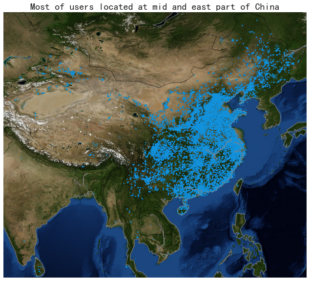

```python
fig = plt.figure(figsize=(16, 10))
m = Basemap(
    projection='mill', lon_0=104.166, lat_0=36.894402,
    llcrnrlon=73.557701, llcrnrlat=5.77539,
    urcrnrlon=134.773605, urcrnrlat=53.5606)
m.bluemarble()
m.drawcoastlines(color = 'gray')
m.drawcountries(color = 'black')
x, y = m(events.longitude.values, events.latitude.values)
m.scatter(x, y, s=1, marker= ',', c="#1292db")
plt.title("Most of users located at mid and east part of China", fontsize = 20)
```

## 1.2 phone brand

back to content

##### 10 most popular brands account for more than 90% of devices.

```
Total 73 brands
```

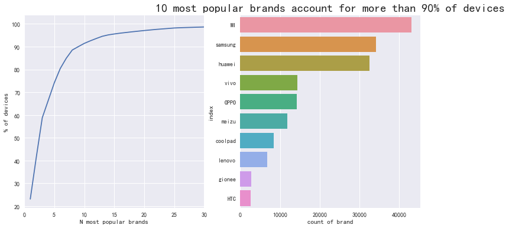

```python
c = phone.brand.value_counts()
s = c.cumsum()/c.sum()
fig, (ax1,ax2) = plt.subplots(1,2,sharey=False,figsize=(12,6))
ax1.plot(np.arange(s.shape[0])+1, s.values*100)
ax1.set_xlim(0,30)
ax1.set_xlabel('N most popular brands')
ax1.set_ylabel('% of devices')
plt.title("10 most popular brands account for more than 90% of devices",fontsize = 20)

brand_count = phone["eng_phone_brand"].value_counts().reset_index().head(10)
ax2 = sns.barplot(y = brand_count["index"],x = brand_count["eng_phone_brand"])
ax2.set_xlabel('count of brand')

print ("Total {} brands".format(phone["eng_phone_brand"].nunique()))
```

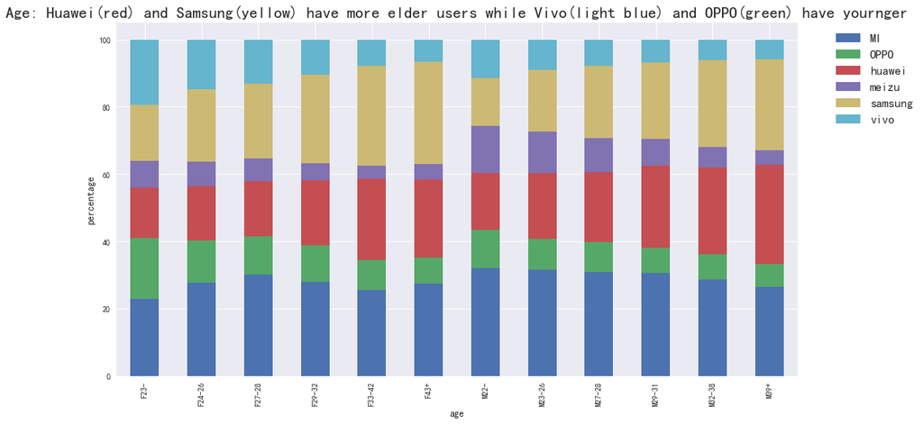

```python
d1 = train_phone.loc[train_phone["eng_phone_brand"].isin(list(brand_count[0:6]["index"]))].groupby(
    ["group","eng_phone_brand"])["age"].count()
d2 = d1.groupby(level=0).apply(lambda x: 100 * x / float(x.sum()))
d2.unstack().plot(kind='bar',stacked=True,figsize=(15,8))
plt.xlabel("age",fontsize=12)
plt.ylabel("percentage",fontsize=12)
plt.title("Age: Huawei(red) and Samsung(yellow) have more elder users while Vivo(light blue) and OPPO(green) have yournger",fontsize = 20)
plt.legend(bbox_to_anchor=(1.04,1), loc="upper left",fontsize  = 15)
```

##### Gender: OPPO, Samsung, and Vivo are preffered by female than male

```
Text(0.5,1,'Gender: Female user prefer Vivo, OPPO, and Samsung')
```

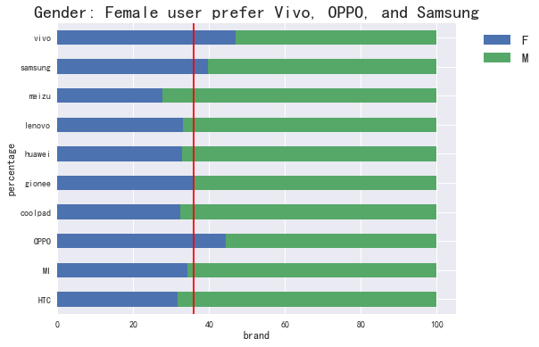

```python
d1 = train_phone.loc[train_phone["eng_phone_brand"].isin(list(brand_count["index"]))].groupby(
    ["eng_phone_brand","gender"])["age"].count()
d2 = d1.groupby(level=0).apply(lambda x: 100 * x / float(x.sum()))
d2.unstack().plot(kind='barh',stacked=True,figsize = (8,6))
plt.axvline(d2.unstack()["F"].mean(),color = "red")
plt.xlabel("brand",fontsize = 12)
plt.ylabel("percentage",fontsize = 12)
plt.legend(bbox_to_anchor=(1.04,1), loc="upper left",fontsize = 15)
plt.title("Gender: Female user prefer Vivo, OPPO, and Samsung", fontsize = 20)
```

## 1.5 APP Label

back to content

[figure not shown]

```python
age_by_cat = devicelabels.groupby(["category"])["age"].agg(['median','count']).dropna().\
reset_index().loc[lambda df:df["count"]>df["count"].median()].sort_values(by="median")
age_by_cat = pd.concat([age_by_cat.head(5),age_by_cat.tail(5)])

d1 = devicelabels.loc[devicelabels["category"].isin(age_by_cat["category"].values)].groupby(
    ["group","category"])["group"].count()
d2 = d1.groupby(level=0).apply(lambda x: 100 * x / float(x.sum()))
d2.unstack().plot(kind='bar',stacked=True,figsize=(15,10))
plt.xlabel("group")
plt.ylabel("percentage")
plt.title("Age: Elder prefer security (yellow) and finance (lower green). Younger prefer animation (upper blue) and games (lower blue)",fontsize=20)
plt.legend(bbox_to_anchor=(1.04,1), loc="upper left",fontsize = 15)
```

##### Gender:

##### APPS related to health, insureance, animation, music and dance game are preferred by female.

##### APPS related to vehicle, strategy game, finance, stock, and japannse and korean style are preferred by male.

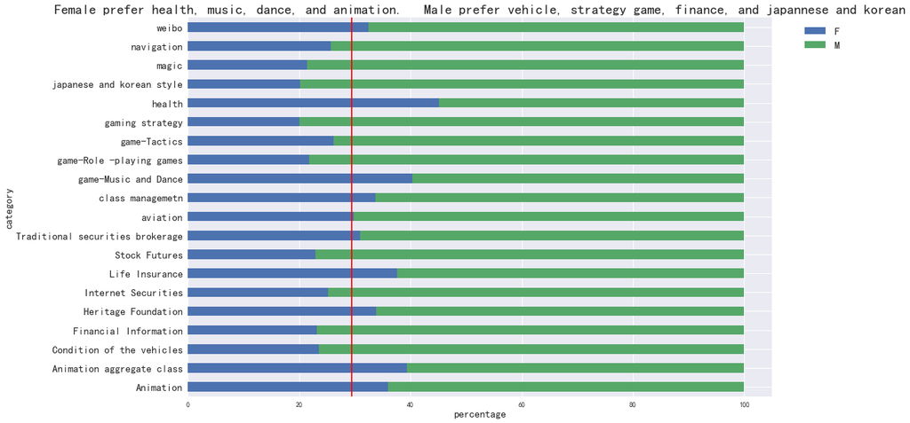

```python
d1 = devicelabels[devicelabels["category"].isin(age_by_cat["category"].values)].groupby(["category","gender"])["age"].count()
d2 = d1.groupby(level=0).apply(lambda x: 100 * x / float(x.sum()))
ax = d2.unstack().plot(kind='barh',stacked=True,figsize=(15,10))
plt.axvline(d2.unstack()["F"].mean(),color = "red")
plt.ylabel("category", fontsize = 15)
plt.xlabel("percentage",fontsize = 15)
plt.legend(bbox_to_anchor=(1.04,1), loc="upper left",fontsize = 15)
plt.title("Female prefer health, music, dance, and animation. \
  Male prefer vehicle, strategy game, finance, and japannese and korean", fontsize = 20)
for tick in ax.get_yticklabels():
    tick.set_fontsize(15)
```

## 1.6 Event trigger time

back to content

```python
def binhour(x):
    if x < 5:
        return "midnight"
    elif x < 8:
        return "early morning"
    elif x < 20:
        return "daytime"
    elif x< 23:
        return "night"
    else:
        return "midnight"
```

##### Younger Users trigger APP more during midnight while elders trigger more during early morning

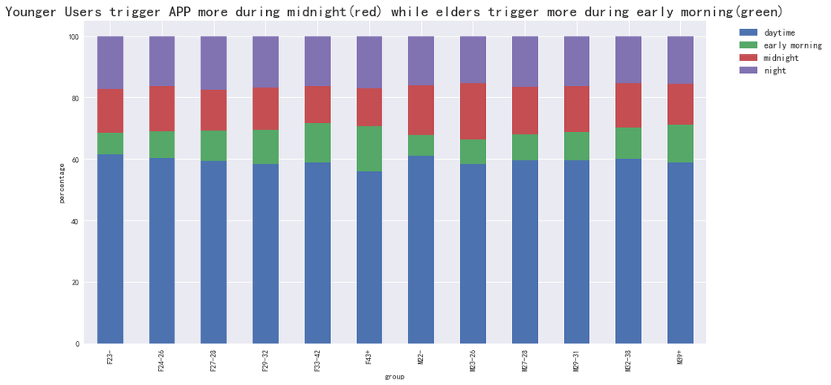

```python
d1 = eventod.groupby(["group","hour2"])["size"].sum()
d2 = d1.groupby(level=0).apply(lambda x: 100 * x / float(x.sum()))
d2.unstack().plot(kind='bar',stacked=True,figsize=(15,8))
plt.xlabel("group")
plt.ylabel("percentage")
plt.title("Younger Users trigger APP more during midnight(red) while elders trigger more during early morning(green)",fontsize=20)
plt.legend(bbox_to_anchor=(1.04,1), loc="upper left",fontsize = 12)
```

# 2. Modeling

#### 2.1 Logistic Model

#### 2.2 XGBoost

#### 2.3 Random Forest

back to content

```python
#Xtrain = hstack((Xtr_brand, Xtr_app, Xtr_label), format='csr')
#Xtest =  hstack((Xte_brand, Xte_app, Xte_label), format='csr')
#Xtrain = hstack((Xtr_brand_top10, Xtr_app, Xtr_label), format='csr')
#Xtest =  hstack((Xte_brand_top10, Xte_app, Xte_label), format='csr')
#Xtr_brand, Xtr_model, Xtr_app, Xtr_label,Xtr_tod,Xtr_brand_top10, Xtr_label_topbot10
#Xte_brand, Xte_model, Xte_app, Xte_label,Xte_tod, Xte_brand_top10, Xte_label_topbot10

Xtrain = hstack((Xtr_brand_top10, Xtr_model, Xtr_app, Xtr_label, Xtr_tod), format='csr')
Xtest =  hstack((Xte_brand_top10, Xte_model, Xte_app, Xte_label, Xte_tod), format='csr')
print('All features: train shape {}, test shape {}'.format(Xtrain.shape, Xtest.shape))
```

```
All features: train shape (74645, 21411), test shape (112071, 21411)
```

#### 2.0.2 Prepare a cross validation function to calculate log loss for each model

[figure not shown]

```python
def cv_los (k,model,Xtrain,Ytrain,**kwargs):
    error = []
    kf = StratifiedKFold(Ytrain, n_folds = k, shuffle=True)
    #loop through K fold
    for i, (train_index, test_index) in enumerate(kf):#get the train and test index generated by Kfold
        x_tr = Xtrain[train_index,:] #xtrain for a fold
        y_tr = Ytrain[train_index] #ytrain for a fold
        x_te = Xtrain[test_index,:]  #xtest for a fold
        y_te = Ytrain[test_index]  #ytest for a fold

        #predict and calculate rmsle
        pred_yte = globals()[model](x_tr,y_tr,x_te,**kwargs)
        error.append(log_loss(y_te, pred_yte))
        print("finish {} round of {}, log_loss = {}".format(i,model,log_loss(y_te, pred_yte)))
    return error
```

## 2.1 Logistic Regression

back to content

#### 2.1.1 Find optimal C (smaller values specify stronger regularization) and solver

```python
def eval_logit(train_x,train_y,clf, random_state = 0):
    kf = StratifiedKFold(train_y, n_folds=4, shuffle=True, random_state=random_state)
    pred = np.zeros((train_y.shape[0],nclasses))
    for itrain, itest in kf:
        Xtr, Xte = train_x[itrain, :], train_x[itest, :]
        ytr, yte = train_y[itrain], train_y[itest]
        clf.fit(Xtr, ytr)
        pred[itest,:] = clf.predict_proba(Xte)
        #print("{:.5f}".format(log_loss(yte, pred[itest,:])), end=' ')
    #print('')
    return log_loss(train_y, pred)


def opt_logit_parm(train_x,train_y,random_state = 0, C = 0.02, solver = 'lbfgs', Cs = None, solvers = None):
    #C: smaller values specify stronger regularization
    #solver: ‘newton-cg’, ‘sag’, and ‘lbfgs’
    if list(Cs) and solvers:
        try:
            for solver in solvers:
                res = []
                for C in Cs:
                    clf = LogisticRegression(C = C, multi_class='multinomial', solver=solver)
                    los_score = eval_logit(train_x,train_y,clf,random_state)
                    print("C = {},solver = {}, log_loss = {}".format(C,solver,los_score))
                    res.append(los_score)
                plt.plot(Cs, res,'-o',label = solver)
            plt.legend()
            #plt.xticks(rotation='vertical')
            return
        except:
            print("error")
            return

    try:
        res = []
        for C in Cs:
            print("C = {},solver = {}".format(C,solver))
            clf = LogisticRegression(C = C, multi_class='multinomial', solver=solver)
            res.append(eval_logit(train_x,train_y,clf,random_state))
        plt.semilogx(Cs, res,'-o')
        C = Cs[np.array(res).argmin()] #set C with smallest log_loss when test solver
    except:
        print("no 'C' to be evaluated")

    try:
        for solver in solvers:
            print("C = {},solver = {}".format(C,solver))
            clf = LogisticRegression(C = C, multi_class='multinomial', solver=solver)
            los_score = eval_logit(train_x,train_y,clf,random_state)
            print("Solver {} has a log_loss score of {}".format(solver,los_score))
            print("")
    except:
        print("no 'solver' to be evaluated")
```

```
C = 0.018,solver = newton-cg, log_loss = 2.2753161106876347
C = 0.019,solver = newton-cg, log_loss = 2.275274233719862
C = 0.02,solver = newton-cg, log_loss = 2.2752746325050786
C = 0.018,solver = lbfgs, log_loss = 2.2755139021753656
C = 0.019,solver = lbfgs, log_loss = 2.275446784816526
C = 0.02,solver = lbfgs, log_loss = 2.275438468174512
```

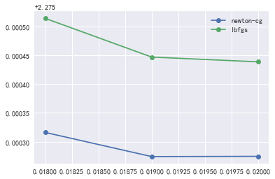

```python
solvers = ["newton-cg","lbfgs"]  #handle multinomial loss and L2 penalty
Cs = np.array([0.018,0.019,0.02])
opt_logit_parm(Xtrain,Ytrain,Cs = Cs,solvers=solvers)
```

#### 2.1.2 cross validation

```python
def logistic_reg(train_x,train_y,test_x,C=0.019,solver = 'newton-cg'):
    clf = LogisticRegression(C=C, multi_class='multinomial',solver=solver)
    clf.fit(train_x, train_y)
    pred = clf.predict_proba(test_x)
    return pred
```

```python
#check log_loss with cross validation to compare models
k = 5
model = "logistic_reg"
model_params = {
   "C": 0.019,
    "solver": 'newton-cg'
}
error = cv_los(k, model, Xtrain,Ytrain,**model_params)
error
print("The cross validation log_loss of {} is {}".format(model,round(np.mean(error),4)))
```

```
finish 0 round of logistic_reg, log_loss = 2.275117516056449
finish 1 round of logistic_reg, log_loss = 2.2791510895272955
finish 2 round of logistic_reg, log_loss = 2.262356984150742
finish 3 round of logistic_reg, log_loss = 2.2748589428828434
finish 4 round of logistic_reg, log_loss = 2.2740939621290743
```

```
[2.275117516056449,
 2.2791510895272955,
 2.262356984150742,
 2.2748589428828434,
 2.2740939621290743]
```

```
The cross validation log_loss of logistic_reg is 2.2731
```

## 2.2 XGBoost

back to content

```python
import xgboost as xgb
```

#### 2.2.1 grid search to find optimal parameters

```python
class XGBoostClassifier():
    def __init__(self, num_boost_round=50, **params):
        self.clf = None
        self.num_boost_round = num_boost_round
        self.params = params
        self.params.update({'objective': 'multi:softprob'})

    def fit(self, X, y, num_boost_round=None):
        num_boost_round = num_boost_round or self.num_boost_round
        self.label2num = {label: i for i, label in enumerate(sorted(set(y)))}
        dtrain = xgb.DMatrix(X, label=[self.label2num[label] for label in y])
        self.clf = xgb.train(params=self.params, dtrain=dtrain, num_boost_round=num_boost_round)

    def predict(self, X):
        num2label = {i: label for label, i in self.label2num.items()}
        Y = self.predict_proba(X)
        y = np.argmax(Y, axis=1)
        return np.array([num2label[i] for i in y])

    def predict_proba(self, X):
        dtest = xgb.DMatrix(X)
        return self.clf.predict(dtest)

    def score(self, X, y):
        Y = self.predict_proba(X)
        return 1 / logloss(y, Y)

    def get_params(self, deep=True):
        return self.params

    def set_params(self, **params):
        if 'num_boost_round' in params:
            self.num_boost_round = params.pop('num_boost_round')
        if 'objective' in params:
            del params['objective']
        self.params.update(params)
        return self


def logloss(y_true, Y_pred):
    label2num = dict((name, i) for i, name in enumerate(sorted(set(y_true))))
    return -1 * sum(math.log(y[label2num[label]]) if y[label2num[label]] > 0 else -np.inf for y, label in zip(Y_pred, y_true)) / len(Y_pred)
```

```python
#grid search
model = XGBoostClassifier(num_class = nclasses, eval_metric = 'mlogloss')
parameters = {
    'n_estimators': [100],
    'eta': [0.05],
    'subsample': [0.7,0.8,0.9], #0.5 means that XGBoost randomly collected half of the data instances to grow trees and this will prevent overfitting
    'colsample_bytree': [0.7,0.8,0.9], #subsample ratio of columns when constructing each tree
    'gamma':[0,0.1,0.2], #minimum loss reduction required to make a further partition on a leaf node of the tree. The larger, the more conservative the algorithm will be.
    'max_depth':range(6,12,2), #default 5, increase this value will make the model more complex / likely to be overfitting
    'min_child_weight':range(1,6,2) #default 1, The larger, the more conservative the algorithm will be
}

grid_obj = GridSearchCV(model, parameters, scoring="neg_log_loss", n_jobs=1, cv=5)
grid_obj = grid_obj.fit(Xtrain, Ytrain)

#grid search result
best_parameters, score, _ = max(grid_obj.grid_scores_, key=lambda x: x[1])
best_parameters
score
```

```
{'colsample_bytree': 0.9,
 'eta': 0.05,
 'gamma': 0.1,
 'max_depth': 10,
 'min_child_weight': 5,
 'n_estimators': 100,
 'subsample': 0.8}
```

```
-2.334699416002878
```

#### 2.2.2 find optimal num of boosting round

```python
def opt_num_boost_round(train_x,train_y,xgb_params):
    dtrain = xgb.DMatrix(train_x, train_y)
    cv_output = xgb.cv(xgb_params, dtrain, num_boost_round=200, early_stopping_rounds=100,
        verbose_eval=20, show_stdv=False)
    cv_output[['train-mlogloss-mean', 'test-mlogloss-mean']].plot()

def xgb_model(train_x,train_y,test_x,xgb_params,num_round):
    dtrain = xgb.DMatrix(train_x, train_y)
    xgb_model = xgb.train(dict(xgb_params, silent=0), dtrain, num_boost_round=num_round)
    pred = xgb_model.predict(xgb.DMatrix(test_x))
    return pred
```

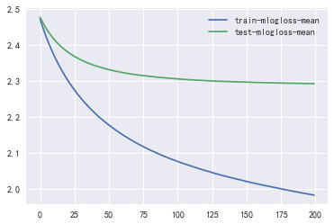

```python
xgb_params = {
    'eta': 0.05,
    'max_depth': 10,
    'min_child_weight': 5,
    'subsample': 0.8,
    'colsample_bytree': 0.9,
    'gamma': 0.1,
    "booster" : "gbtree",
    'objective': 'multi:softprob',
    'num_class': nclasses,
    'eval_metric': 'mlogloss',
    'silent': 1
}

opt_num_boost_round(dtrain_X,dtrain_y,xgb_params)
```

#### 2.2.3 cross validation

```python
k = 5
model = "xgb_model"
model_params = {
   "xgb_params": xgb_params,
    "num_round": 100
}
error = cv_los(k, model, Xtrain,Ytrain,**model_params)
error
print("The cross validation log_loss of {} is {}".format(model,round(np.mean(error),4)))
```

```
finish 0 round of xgb_model, log_loss = 2.313976900297184
finish 1 round of xgb_model, log_loss = 2.3084480110283914
finish 2 round of xgb_model, log_loss = 2.300536714634956
finish 3 round of xgb_model, log_loss = 2.311252027763991
finish 4 round of xgb_model, log_loss = 2.302243680638484
```

```
[2.313976900297184,
 2.3084480110283914,
 2.300536714634956,
 2.311252027763991,
 2.302243680638484]
```

```
The cross validation log_loss of xgb_model is 2.3073
```

## 2.3 Random Forest

back to content

```python
from sklearn.ensemble import RandomForestClassifier
```

#### 2.3.1 grid search best parameters

```python
model = RandomForestClassifier()
parameters = {'n_estimators': [500],
              'max_features': ['log2', 'sqrt','auto'], #The number of features to consider when looking for the best split
              'max_depth': [50,80,100,150],
              'min_samples_split': [5,7,9,11],
             }
grid_obj = GridSearchCV(model, parameters, scoring="neg_log_loss",n_jobs=4,cv = 5)
grid_obj = grid_obj.fit(dtrain_X,dtrain_y)
model_params = grid_obj.best_params_
model_params
```

```
{'max_depth': 100,
 'max_features': 'sqrt',
 'min_samples_split': 9,
 'n_estimators': 500}
```

#### 2.3.2 cross validation

```python
def random_forest(train_x,train_y,test_x,**kwargs):
    forest = RandomForestClassifier(**kwargs)
    forest.fit(train_x, train_y)
    pred_y = forest.predict_proba(test_x)
    return pred_y
```

```python
k = 5
model = "random_forest"
error = cv_los(k, model, Xtrain,Ytrain,**model_params)
error
print("The cross validation log_loss of {} is {}".format(model,round(np.mean(error),4)))
```

```
finish 0 round of random_forest, log_loss = 2.3170293259019044
finish 1 round of random_forest, log_loss = 2.323108505602345
finish 2 round of random_forest, log_loss = 2.3190350524380374
finish 3 round of random_forest, log_loss = 2.314580427216513
finish 4 round of random_forest, log_loss = 2.313810386252836
```

```
[2.3170293259019044,
 2.323108505602345,
 2.3190350524380374,
 2.314580427216513,
 2.313810386252836]
```

```
The cross validation log_loss of random_forest is 2.3175
```

## 2.4 Model Comparison

back to content

[figure not shown]

##### From the table above, the Logistic model beats XGBoost and Random Forest and have the best performance (lowest CV loss score)

##### The model have better performance after adding trigger time into featuers, and have no significant difference between using the whole brand set and only top 10 brand (which includes more than 90% devices)

##### So the Logistic model on third set of features will be choosen for our final model

## 2.5 Model Visualization

back to content

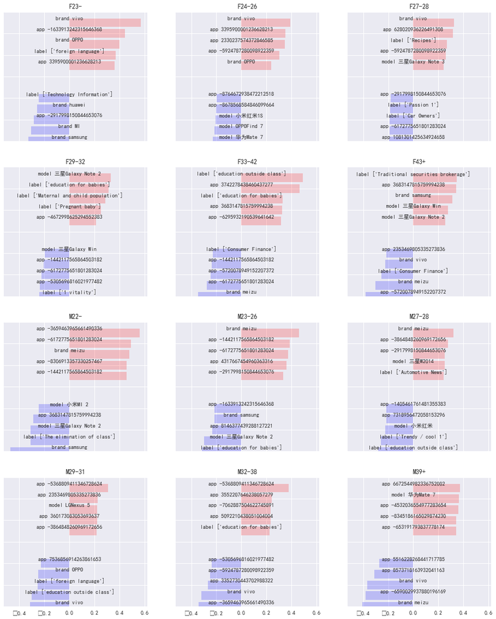

```python
N = 5 # Number of positive and negative traits to plot
fig, ax = plt.subplots(4,3, figsize=(16,20), sharex=True)
ax = ax.flatten()
for i in range(12):
    ax[i].set_title(targetencoder.classes_[i])
    ind = np.argsort(coef[i,:])
    for n in range(N):
        ax[i].barh([-(N-n)-1], [coef[i,ind[n]]], color='b',alpha=0.2)
        ax[i].text(0, -(N-n)-0.6, map_feature(ind[n]),
                   horizontalalignment='center',
                   verticalalignment = 'center')
        ax[i].barh([N-n], [coef[i,ind[-n-1]]], color='r',alpha=0.2)
        ax[i].text(0, N-n+0.4, map_feature(ind[-n-1]),
                   horizontalalignment='center',
                   verticalalignment = 'center')
        ax[i].set_ylim(-N-1,N+1)
    ax[i].set_yticklabels([''])
```

# Reference

back to content  
https://www.kaggle.com/dvasyukova/a-linear-model-on-apps-and-labels  
https://www.kaggle.com/dvasyukova/user-portraits  
https://www.kaggle.com/tanitter/grid-search-xgboost-with-scikit-learn  
https://www.kaggle.com/poiss0nriot/bag-of-apps-keras-11-08-16-no-val/code